# CSSS 508, Week 8: Strings

Charles Lanfear  
May 16, 2018

### Data Today

We'll use data on food safety inspections in King County from [data.kingcounty.gov](https://data.kingcounty.gov/Health/Food-Establishment-Inspection-Data/f29f-zza5).

Note these data are *quite large*. You will want to save them and load them from a *local directory*.

```r
library(tidyverse)
restaurants <-
  read_csv("https://clanfear.github.io/CSSS508/Lectures/Week8/restaurants.csv",
                        col_types = "ccccccccnnccicccciccciD")
```

### Strings

A general programming term for a unit of character data is a **string**, which is defined as *a sequence of characters*. In R the terms “strings” and “character data” are mostly interchangeable.

In other languages, a string often also refers a *sequence* of numeric information, such as binary strings (e.g. “01110000 01101111 01101111 01110000”).

Note that these are *sequences* of numbers rather than single numbers, and thus *strings*.

## Basic String Things

### nchar()

We've seen the `nchar()` function to get the number of characters in a string. How many characters are in the ZIP codes?

```r
restaurants %>%
  mutate(ZIP_length = nchar(Zip_Code)) %>%
    group_by(ZIP_length) %>% tally()
```

```
# A tibble: 2 x 2
  ZIP_length      n
       <int>  <int>
1          5 258629
2         10      1
```

### substr()

You may be familiar with `substr()` from the voting homework. We can use it to pull out just the first 5 digits of the ZIP code.

```r
restaurants <- restaurants %>%
    mutate(ZIP_5 = substr(Zip_Code, 1, 5))
head(unique(restaurants$ZIP_5))
```

```
[1] "98126" "98109" "98101" "98032" "98102" "98004"
```

### paste()

We can combine parts of strings together using the `paste()` function, e.g. to make a whole mailing address:

```r
restaurants <- restaurants %>%
    mutate(mailing_address = paste(Address, ", ", City, ", WA ", ZIP_5, sep = ""))
head(unique(restaurants$mailing_address))
```

```
[1] "2920 SW AVALON WAY, Seattle, WA 98126"
[2] "10 MERCER ST, Seattle, WA 98109"
[3] "1001 FAIRVIEW AVE N Unit 1700A, SEATTLE, WA 98109"
[4] "1225 1ST AVE, SEATTLE, WA 98101"
[5] "18114 E VALLEY HWY, KENT, WA 98032"
[6] "121 11TH AVE E, SEATTLE, WA 98102"
```

### paste() with collapse

`readr` functions can take an argument like `col_types = "cciDcnncii"`. You can build this yourself from existing data using `class()` to get the type of data, and `substr()`, and `paste()` with the `collapse = ""` argument to take a vector and make it a single character string:

```r
# use the class function to get the type of data
column_types <- sapply(restaurants, class)
# extract 1st character
column_types_1 <- substr(column_types, 1, 1)
# use paste with collapse to get one string
(column_types_collapse <- paste(column_types_1, collapse = ""))
```

```
[1] "ccccccccnnccicccciccciDcc"
```

### Make a function out of this!

I typically read in data using `read_csv()` without `col_types()`. You could use the functions above together to get column types to feed back into `read_csv()`:

```r
readr_input_types <- function(data) {
    column_types_1 <- substr(sapply(data, class), 1, 1)
    return(paste(column_types_1, collapse = ""))
}
readr_input_types(swiss)
```

```
[1] "nniinn"
```

```r
readr_input_types(restaurants)
```

```
[1] "ccccccccnnccicccciccciDcc"
```

### paste0()

`paste0()` is a shortcut for `paste()` without any separator.

```r
paste(1:5, letters[1:5]) # sep is a space by default
```

```
[1] "1 a" "2 b" "3 c" "4 d" "5 e"
```

```r
paste(1:5, letters[1:5], sep ="")
```

```
[1] "1a" "2b" "3c" "4d" "5e"
```

```r
paste0(1:5, letters[1:5])
```

```
[1] "1a" "2b" "3c" "4d" "5e"
```

### paste() practice

`sep=` controls what happens when doing entry-wise squishing of vectors you give to `paste()`, while `collapse=` controls if/how they go from a vector to a single string. Here are some examples; make sure you understand how the arguments produce the results:

```r
paste(letters[1:5], collapse = "!")
paste(1:5, letters[1:5], sep = "+")
paste0(1:5, letters[1:5], collapse = "???")
paste(1:5, "Z", sep = "*")
paste(1:5, "Z", sep = "*", collapse = " ~ ")
```

```
[1] "a!b!c!d!e"
[1] "1+a" "2+b" "3+c" "4+d" "5+e"
[1] "1a???2b???3c???4d???5e"
[1] "1*Z" "2*Z" "3*Z" "4*Z" "5*Z"
[1] "1*Z ~ 2*Z ~ 3*Z ~ 4*Z ~ 5*Z"
```

## stringr

### stringr

`stringr` is yet another R package from the Tidyverse (like `ggplot2`, `dplyr`, `tidyr`, `lubridate`, `readr`).

It provides functions that:

- Replace some basic string functions like `paste()` and `nchar()` in a way that's a bit less touchy with missing values or factors
- Remove whitespace or pad it out
- Perform tasks related to **pattern matching**: Detect, locate, extract, match, replace, split.
  - The functions use **regular expressions** to describe patterns
  - Base R and `stringi` versions for these exist but are more confusing to use

Conveniently, most `stringr` functions also begin with “`str_`” to make RStudio auto-complete more useful.

```r
library(stringr)
```

### stringr: Basic function equivalencies

- `str_sub()` is like `substr()` but also lets you put in negative values to count backwards from the end (-1 is the end, -2 is second from end):

```r
str_sub("Washington", 1, -3)
```

```
[1] "Washingt"
```

- `str_c()` (“string combine”) is just like `paste()` but where default is `sep = ""` (like `paste0()`)

```r
str_c(letters[1:5], 1:5)
```

```
[1] "a1" "b2" "c3" "d4" "e5"
```

### stringr: Basic function equivalencies

- `str_length()` is equivalent to `nchar()`:

```r
nchar("weasels")
```

```
[1] 7
```

```r
str_length("weasels")
```

```
[1] 7
```

### Changing Cases

`str_to_upper()`, `str_to_lower()`, `str_to_title()` convert cases, which is often a good idea to do before searching for values:

```r
head(unique(restaurants$City))
```

```
[1] "Seattle"  "SEATTLE"  "KENT"     "BELLEVUE" "KENMORE"  "Issaquah"
```

```r
restaurants <- restaurants %>%
    mutate_at(vars(Name, Address, City), funs(str_to_upper))
head(unique(restaurants$City))
```

```
[1] "SEATTLE"  "KENT"     "BELLEVUE" "KENMORE"  "ISSAQUAH" "BURIEN"
```

### Whitespace and str_trim()

Extra leading or trailing whitespace is common in text data:

```r
head(unique(restaurants$Name), 4)
```

```
[1] "@ THE SHACK, LLC "    "10 MERCER RESTAURANT" "100 LB CLAM"
[4] "1000 SPIRITS"
```

Any character column is potentially affected. We can use the `str_trim()` function in `stringr` to clean them up all at once:

```r
# use mutate_if to trim all the character columns
restaurants <- restaurants %>%
    mutate_if(is.character, str_trim)
head(unique(restaurants$Name), 4)
```

```
[1] "@ THE SHACK, LLC"     "10 MERCER RESTAURANT" "100 LB CLAM"
[4] "1000 SPIRITS"
```

## Regular Expressions and Pattern Matching

### What are Regular Expressions?

**Regular expressions** or **regex**es are how we describe patterns we are looking for in text in a way that a computer can understand. We write an **expression**, apply it to a string input, and then can do things with **matches** we find.

- **Literal characters** are defined snippets to search for like `SEA` or `206`
- **Metacharacters** let us be flexible in describing patterns:
  - backslash `\`, caret `^`, dollar sign `$`, period `.`, pipe `|`, question mark `?`, asterisk `*`, plus sign `+`, parentheses `(` and `)`, square brackets `[` and `]`, curly braces `{` and `}`
  - To treat a metacharacter as a literal character, you must **escape** it with two preceding backslashs `\\`, e.g. to match `(206)` including the parentheses, you'd use `\\(206\\)` in your regex

### Simple regex Searches with str_detect()

I want to get inspections for coffee shops. I'll say a coffee shop is anything that has “COFFEE”, “ESPRESSO”, or “ROASTER” in the name. The `regex` for this is `COFFEE|ESPRESSO|ROASTER` because `|` is a metacharacter that means “OR”. Use the `str_detect()` function, which returns `TRUE` if it finds what you're looking for and `FALSE` if it doesn't (similar to `grepl()`):

```r
coffee <- restaurants %>% filter(str_detect(Name, "COFFEE|ESPRESSO|ROASTER"))
head(unique(coffee$Name))
```

```
[1] "2 SISTERS ESPRESSO"
[2] "701 COFFEE"
[3] "909 COFFEE AND WINE"
[4] "AJ'S ESPRESSO"
[5] "ALKI HOMEFRONT SMOOTHIES & ESPRESSO"
[6] "ALL CITY COFFEE"
```

### Will My Coffee Kill Me?

Let's take each unique business identifier, keep the most recent inspection score, and look at a histogram of scores:

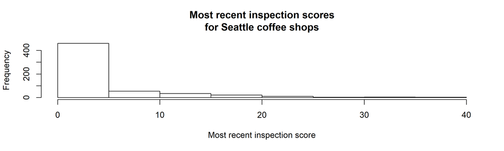

```r
with(coffee %>% select(Business_ID, Name, Inspection_Score, Date) %>% group_by(Business_ID) %>% filter(Date == max(Date)) %>% distinct(.keep_all=TRUE), hist(Inspection_Score, xlab = "Most recent inspection score", main = "Most recent inspection scores\nfor Seattle coffee shops"))
```

### Looking for Patterns with str_detect()

Let's look for phone numbers whose first three digits are “206” using `str_detect()`. We will want it to work whether they have parentheses around the beginning or not, but NOT to match “206” occurring elsewhere:

```r
area_code_206_pattern <- "^\\(?206"
phone_test_examples <- c("2061234567", "(206)1234567", "(206) 123-4567", "555-206-1234")
str_detect(phone_test_examples, area_code_206_pattern)
```

```
[1]  TRUE  TRUE  TRUE FALSE
```

- `^` is a metacharacter meaning “look only at the *beginning* of the string”
- `\\(?` means look for a left parenthesis (`\\(`), but it's optional (`?`)
- `206` is the literal character to look for after the optional parenthesis

### str_view()

`stringr` also has a function called `str_view()` that allows you to see in the viewer pane *exactly* what text is being selected with a regular expression.

```r
str_view(phone_test_examples, area_code_206_pattern)
```

This will generate a small web page in the viewer pane (but not in Markdown docs). Just be careful to not load an entire long vector / variable or it may crash RStudio as it tries to render a massive page!

### How Many Rows Have Non-206 Numbers?

```r
restaurants %>%
  mutate(has_206_number = str_detect(Phone, area_code_206_pattern)) %>%
  group_by(has_206_number) %>% tally()
```

```
# A tibble: 3 x 2
  has_206_number      n
  <lgl>           <int>
1 FALSE           66655
2 TRUE           109099
3 NA              82876
```

### Extracting Patterns with str_extract()

Let's extract the [directional part of Seattle](https://en.wikipedia.org/wiki/Street_layout_of_Seattle#Directionals) an address is in: N, NW, SE, none, etc.

```r
direction_pattern <- " (N|NW|NE|S|SW|SE|W|E)( |$)"
direction_test_examples <- c("2812 THORNDYKE AVE W", "512 NW 65TH ST", "407 CEDAR ST", "15 NICKERSON ST")
str_extract(direction_test_examples, direction_pattern)
```

```
[1] " W"   " NW " NA     NA
```

- The first space will match a space character, then
- `(N|NW|NE|S|SW|SE|W|E)` matches one of the directions in the group
- `( |$)` is a group saying either there is a space after, or it's the end of the address string (`$` means the end of the string)

### Where in the City are the Addresses?

```r
restaurants %>% distinct(Address) %>% mutate(city_region = str_trim(str_extract(Address, direction_pattern))) %>% group_by(city_region) %>% tally() %>% arrange(desc(n))
```

```
# A tibble: 9 x 2
  city_region     n
  <chr>       <int>
1 NE           2086
2 S            1764
3 <NA>         1745
4 N             879
5 SE            868
6 SW            705
7 E             538
8 NW            438
9 W             235
```

### Find/Replacing with str_replace()

Maybe we want to do a street-level analysis of inspections (e.g. compare The Ave to Pike Street). How can we remove building numbers?

```r
address_number_pattern <- "^[0-9]*-?[A-Z]? (1/2 )?"
address_number_test_examples <- c("2812 THORNDYKE AVE W", "1ST AVE", "10A 1ST AVE", "10-A 1ST AVE", "5201-B UNIVERSITY WAY NE", "7040 1/2 15TH AVE NW")
str_replace(address_number_test_examples, address_number_pattern, replacement = "")
```

```
[1] "THORNDYKE AVE W"   "1ST AVE"           "1ST AVE"
[4] "1ST AVE"           "UNIVERSITY WAY NE" "15TH AVE NW"
```

### How Does the Building Number regex Work?

Let's break down `"^[0-9]*-?[A-Z]? (1/2 )?"`:

- `^[0-9]` means look for a digit between 0 and 9 (`[0-9]`) at the beginning (`^`)
- `*` means potentially match more digits after that
- `-?` means optionally (`?`) match a hyphen (`-`)
- `[A-Z]?` means optionally match (`?`) a letter (`[A-Z]`)
- Then we match a space ( )
- `(1/2 )?` optionally matches a ½ followed by a space since this is apparently a thing with some address numbers

### Replacing the Street Numbers with... Nothing

```r
restaurants <- restaurants %>%
  mutate(street_only = str_replace(Address, address_number_pattern, replacement = ""))
head(unique(restaurants$street_only), 12)
```

```
 [1] "SW AVALON WAY"             "MERCER ST"
 [3] "FAIRVIEW AVE N UNIT 1700A" "1ST AVE"
 [5] "E VALLEY HWY"              "11TH AVE E"
 [7] "112TH AVE NE #125"         "NE BOTHELL WAY"
 [9] "NW GILMAN BL C-08"         "NE 20TH ST STE 300"
[11] "S ORCAS ST"                "148TH AVE NE"
```

### Can We Remove Units/Suites Too?

Getting rid of unit/suite references is tricky, but a decent attempt would be to drop anything including and after “#”, “STE”, “SUITE”, “SHOP”, “UNIT”:

```r
address_unit_pattern <- " (#|STE|SUITE|SHOP|UNIT).*$"
address_unit_test_examples <- c("1ST AVE", "RAINIER AVE S #A", "FAUNTLEROY WAY SW STE 108", "4TH AVE #100C", "NW 54TH ST")
str_replace(address_unit_test_examples, address_unit_pattern, replacement = "")
```

```
[1] "1ST AVE"           "RAINIER AVE S"     "FAUNTLEROY WAY SW"
[4] "4TH AVE"           "NW 54TH ST"
```

### How'd the Unit regex Work?

Breaking down `" (|#|STE|SUITE|SHOP|UNIT).*$"`:

- First we match a space
- `(#|STE|SUITE|SHOP|UNIT)` matches one of those words
- `.*$` matches *any* character (`.`) after those words, zero or more times (`*`), until the end of the string (`$`)

### Removing Units/Suites in Restaurant Data

```r
restaurants <- restaurants %>%
  mutate(street_only = str_trim(str_replace(street_only, address_unit_pattern, replacement = "")))
head(unique(restaurants$street_only), 15)
```

```
 [1] "SW AVALON WAY"     "MERCER ST"         "FAIRVIEW AVE N"
 [4] "1ST AVE"           "E VALLEY HWY"      "11TH AVE E"
 [7] "112TH AVE NE"      "NE BOTHELL WAY"    "NW GILMAN BL C-08"
[10] "NE 20TH ST"        "S ORCAS ST"        "148TH AVE NE"
[13] "NE 12TH ST"        "AURORA AVE N"      "PACIFIC HWY S"
```

### Which Streets had the Most Restaurants with Scores Above 45?

Let's get one row per restaurant per date with the score, and see which streets the ones above 45 are on:

```r
restaurants %>%
  select(Business_ID, Name, Date, Inspection_Score, street_only) %>%
  distinct() %>% filter(Inspection_Score > 45) %>%
  group_by(street_only) %>%
  tally() %>%
  arrange(desc(n)) %>%
  head(n=5)
```

```
# A tibble: 5 x 2
  street_only           n
  <chr>             <int>
1 UNIVERSITY WAY NE   108
2 S JACKSON ST        105
3 PACIFIC HWY S        90
4 NE 24TH ST           76
5 RAINIER AVE S        70
```

### Splitting up Strings

You can split up strings using `tidyr::separate()`, seen in Week 5. Another option is `str_split()`, which will split strings based on a pattern separating parts and put these components in a list. `str_split_fixed()` will do that but with a matrix instead (and thus can't have varying numbers of separators):

```r
head(str_split_fixed(restaurants$Violation_Description, " - ", n = 2))
```

```
     [,1]
[1,] ""
[2,] "4300"
[3,] "4800"
[4,] "1200"
[5,] "4100"
[6,] "2120"
     [,2]
[1,] ""
[2,] "Non-food contact surfaces maintained and clean"
[3,] "Physical facilities properly installed,..."
[4,] "Proper shellstock ID; wild mushroom ID;  parasite destruction procedures for fish"
[5,] "Warewashing facilities properly installed,..."
[6,] "Proper cold holding temperatures ( 42 degrees F to 45 degrees F)"
```

### Other Useful stringr Functions

`str_pad(string, width, side, pad)` - Adds “padding” to any string to make it a given minimum width.

`str_subset(string, pattern)` - Returns all elements that contain matches of the pattern.

`str_which(string, pattern)` - Returns numeric indices of elements that match the pattern.

`str_replace_all(string, pattern, replacement)` - Performs multiple replacements simultaneously

## Coming Up

Homework 6, Part 2 is due next week, and peer reviews due the week after.

1. **Text Mining and Twitter Data**
   - Accessing and working with social media data
   - Doing text analysis
2. **Tidy Model Results and Applied Data Manipulation**
   - Creating regression tables and predicted value plots.
   - Working example of complex variable creation, data reshaping.